# 474253

## 注意

本项目代码包含多个文件, 需要使用GPU环境来运行后, 才能看到项目完整代码并正确运行:

[figure not shown]

并请检查相关参数设置, 例如use_gpu, fluid.CUDAPlace(0)等处是否设置正确.

# 简介

DeepLabv3+ 是DeepLab语义分割系列网络的最新作，其前作有 DeepLabv1，DeepLabv2, DeepLabv3, 在最新作中，DeepLab的作者通过encoder-decoder进行多尺度信息的融合，同时保留了原来的空洞卷积和ASSP层， 其骨干网络使用了Xception模型，提高了语义分割的健壮性和运行速率，在 PASCAL VOC 2012 dataset取得新的state-of-art performance，89.0mIOU。

[figure not shown]

论文原文：[Encoder-Decoder with Atrous Separable Convolution for Semantic Image Segmentation](https://arxiv.org/abs/1802.02611)

# 数据格式

解压数据集，并通过work/DataPartition随机生成训练集和验证集，数据集构成如下：

- data/ 数据目录
- - iccv09Data/ 存放数据的目录
- - - images/ 用于存放图像
- - - - a.jpg 图像样本a
- - - labels/ 用于存放标签
- - - - a..regions.txt 图像a对应的标签
- - train_list.txt 随机生成的训练数据列表，每一行代表一个样本，包含该行样本的原始图像路径以及标签路径，中间以空格隔开
- - eval_list.txt 随机生成的验证数据列表，格式同train_list.txt # 文件结构

    ```
    |--freeze.py                # 固化模型
    |--infer.py             # 模型推断
    |--eval.py              # 模型验证
    |--config.py                # 模型参数
    |--train.py             # 模型训练脚本
    |--work                 # 通用代码目录
    |--|--DataPartition.py          # 数据预处理脚本
    |--|--reader.py             # 数据读取脚本
    |--|--utils.py              # 通用工具
    |--|--loss.py               # 定义损失
    |--|--model.py              # 模型定义
    ```

    # paddle model zoo 我们为了节约更多的显存，在这里我们使用Group Norm作为我们的归一化手段。如果需要使用BN 可以在config中进行修改 如果需要从头开始训练模型，用户需要下载paddle model zoo中的初始化模型

    ```
    wget https://paddle-deeplab.bj.bcebos.com/deeplabv3plus_gn_init.tgz
    mkdir pretrained\ model
    tar -xf deeplabv3plus_gn_init.tgz -C pretrained\ model/ && rm deeplabv3plus_gn_init.tgz
    ```

```python
# 查看当前挂载的数据集目录，并解压数据集，完成生成操作
!ls /home/aistudio/data/
!tar -xf /home/aistudio/data/data9270/iccv09Data.tar -C /home/aistudio/data/
!python /home/aistudio/work/DataPartition.py
```

```
data9270
```

```python
# 下载paddle model zoo中预训练的模型
!wget https://paddle-deeplab.bj.bcebos.com/deeplabv3plus_gn.tgz
!mkdir pretrained\ model
!tar -xf deeplabv3plus_gn.tgz -C pretrained\ model/ && rm deeplabv3plus_gn.tgz
```

```
--2019-08-27 10:48:21--  https://paddle-deeplab.bj.bcebos.com/deeplabv3plus_gn.tgz
Resolving paddle-deeplab.bj.bcebos.com (paddle-deeplab.bj.bcebos.com)... 182.61.200.229, 182.61.200.195
Connecting to paddle-deeplab.bj.bcebos.com (paddle-deeplab.bj.bcebos.com)|182.61.200.229|:443... connected.
HTTP request sent, awaiting response... 200 OK
Length: 152650268 (146M) [application/x-gzip]
Saving to: ‘deeplabv3plus_gn.tgz.1’

deeplabv3plus_gn.tg 100%[===================>] 145.58M  30.6MB/s    in 4.2s

2019-08-27 10:48:26 (34.7 MB/s) - ‘deeplabv3plus_gn.tgz.1’ saved [152650268/152650268]
```

开始训练过程，训练中的具体参数可以在config.py文件中修改，默认使用Gpu进行训练，目前训练中暂时保存的模型保存在train model路径下，训练时的log存在logs路径下，当paddle_flag参数都设置为1时，忽略continue_train参数，既使用paddle model zoo中预训练好的模型进行fine tuning；当continue_train参数为1且paddle_flag参数为0时，使用train_model目录（该目录可在config中进行修改）下暂存的模型继续训练；当continue_train和paddle_flag都为0时，随机初始化模型参数并开始训练

```python
!python train.py --use_gpu 1 --continue_train 1 --paddle_flag 0 --num_epochs 1
```

```
W0827 17:47:26.304126   593 device_context.cc:259] Please NOTE: device: 0, CUDA Capability: 70, Driver API Version: 9.2, Runtime API Version: 9.0
W0827 17:47:26.307126   593 device_context.cc:267] device: 0, cuDNN Version: 7.3.
2019-08-27 17:47:26,340 - train.py[line:109] - INFO: train params:{'data_augmentation_config': {'use_augmentation': False, 'min_resize': 0.5, 'max_resize': 4, 'crop_size': 240}, 'eval_file_path': 'data/eval_list.txt', 'depthwise_use_cudnn': False, 'base_lr': 0.001, 'default_norm_type': 'gn', 'infer_…
2019-08-27 17:47:26,895 - train.py[line:44] - INFO: ***************已读入预先训练的模型，并准备继续训练***************
2019-08-27 17:47:26,896 - train.py[line:114] - INFO: ***************训练开始***************
2019-08-27 17:47:37,228 - train.py[line:132] - INFO: epoch: 0 step: 100 loss:1.4176461696624756 period:0.33 sec
2019-08-27 17:47:46,596 - train.py[line:132] - INFO: epoch: 0 step: 200 loss:1.558440923690796 period:0.33 sec
2019-08-27 17:47:56,461 - train.py[line:132] - INFO: epoch: 0 step: 300 loss:1.2766289710998535 period:0.33 sec
2019-08-27 17:48:05,262 - train.py[line:132] - INFO: epoch: 0 step: 400 loss:1.353928565979004 period:0.33 sec
2019-08-27 17:48:07,291 - train.py[line:137] - INFO: 0's epoch_total_time: 16.00 sec && mean_loss: 1.4204771774155753
2019-08-27 17:48:07,292 - train.py[line:140] - INFO: 暂时存储第0个epoch的训练结果
2019-08-27 17:48:10,819 - train.py[line:142] - INFO: ***************训练完成***************
```

将训练好的模型参数固化，并保存在infer model路径下

```python
!python freeze.py
```

在验证集上测试训练好的模型的mIoU指数，并输出

```python
# 由于本示例中仅仅微调了一个epoch，所以模型的性能不是很好
!python eval.py
```

```
memory_optimize is deprecated. Use CompiledProgram and Executor
W0827 17:48:46.752137   729 device_context.cc:259] Please NOTE: device: 0, CUDA Capability: 70, Driver API Version: 9.2, Runtime API Version: 9.0
W0827 17:48:46.755635   729 device_context.cc:267] device: 0, cuDNN Version: 7.3.
eval done! total number of image is 112, mean iou: 0.25738463049528865
```

使用固化的模型进行分割，并将分割结果保存为result.jpg

```
运行结束，origin为预测图片，result为分割后的图片
```

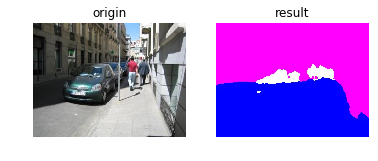

```python
# 使用test数据集的一副图像进行模型推断，并将分割的结果保存在根目录下
!python infer.py

%matplotlib inline
import matplotlib.pyplot as plt
img1 = plt.imread('origin.jpg')
img2 = plt.imread('result.jpg')
fig = plt.figure()
ax = fig.add_subplot(121)
ax.imshow(img1)
ax.set_title('origin')
ax.axis('off')
ax = fig.add_subplot(122)
ax.imshow(img2)
ax.set_title('result')
ax.axis('off')
plt.show()
```